# purchase_order

Autogenerated data summary from dataMaid

2024-03-13 14:25:13.930294

# Data report overview

The dataset examined has the following dimensions:

| Feature | Result |
| --- | --- |
| Number of observations | 100 |
| Number of variables | 21 |

### Checks performed

The following variable checks were performed, depending on the data type of each variable:

|  | character | factor | labelled | haven labelled | numeric | integer | logical | Date |
| --- | --- | --- | --- | --- | --- | --- | --- | --- |
| Identify miscoded missing values | × | × | × | × | × | × |  | × |
| Identify prefixed and suffixed whitespace | × | × | × | × |  |  |  |  |
| Identify levels with < 6 obs. | × | × | × | × |  |  |  |  |
| Identify case issues | × | × | × | × |  |  |  |  |
| Identify misclassified numeric or integer variables | × | × | × | × |  |  |  |  |
| Identify outliers |  |  |  |  | × | × |  | × |

Please note that all numerical values in the following have been rounded to 2 decimals.

# Summary table

|  | Variable class | # unique values | Missing observations | Any problems? |
| --- | --- | --- | --- | --- |
| Purchase.Date | Date | 90 | 0.00 % |  |
| Fiscal.Year | factor | 3 | 0.00 % | × |
| LPA.Number | character | 16 | 0.00 % | × |
| Purchase.Order.Number | character | 100 | 0.00 % | × |
| Acquisition.Type | factor | 3 | 0.00 % | × |
| Sub.Acquisition.Type | factor | 3 | 0.00 % | × |
| Acquisition.Method | factor | 10 | 0.00 % | × |
| Supplier.Code | character | 69 | 0.00 % | × |
| Supplier.Qualifications | character | 8 | 0.00 % | × |
| Quantity | numeric | 34 | 0.00 % | × |
| Unit.Price | numeric | 93 | 0.00 % | × |
| Total.Price | numeric | 98 | 0.00 % | × |
| Classification.Codes | character | 75 | 0.00 % | × |
| Normalized.UNSPSC | character | 75 | 0.00 % | × |
| Commodity.Title | character | 75 | 0.00 % | × |
| Class | factor | 58 | 0.00 % | × |
| Class.Title | character | 58 | 0.00 % | × |
| Family | factor | 36 | 0.00 % | × |
| Family.Title | character | 36 | 0.00 % | × |
| Segment | factor | 21 | 0.00 % | × |
| Segment.Title | factor | 21 | 0.00 % | × |

# Variable list

## Purchase.Date

| Feature | Result |
| --- | --- |
| Variable type | Date |
| Number of missing obs. | 0 (0 %) |
| Number of unique values | 90 |
| Mode | “2013-05-22” |
| Min. and max. | 2012-09-05; 2014-07-07 |
| 1st and 3rd quartiles | 2013-04-13; 2014-03-06 |

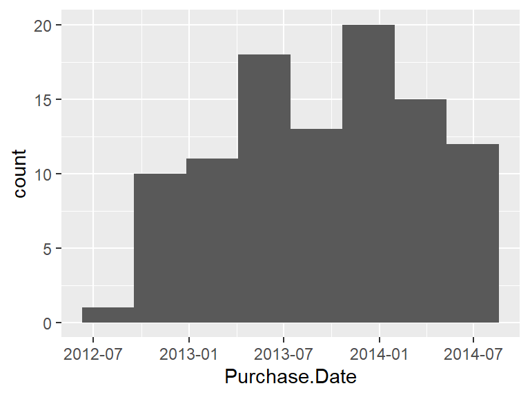

## Fiscal.Year

| Feature | Result |
| --- | --- |
| Variable type | factor |
| Number of missing obs. | 0 (0 %) |
| Number of unique values | 3 |
| Mode | “2013-2014” |
| Reference category | 2012-2013 |

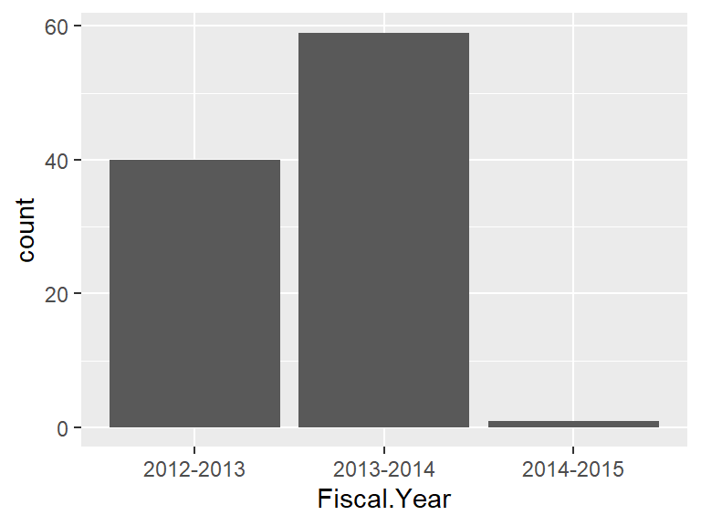

- Note that the following levels have at most five observations: "2014-2015".

## LPA.Number

| Feature | Result |
| --- | --- |
| Variable type | character |
| Number of missing obs. | 0 (0 %) |
| Number of unique values | 16 |
| Mode | “” |

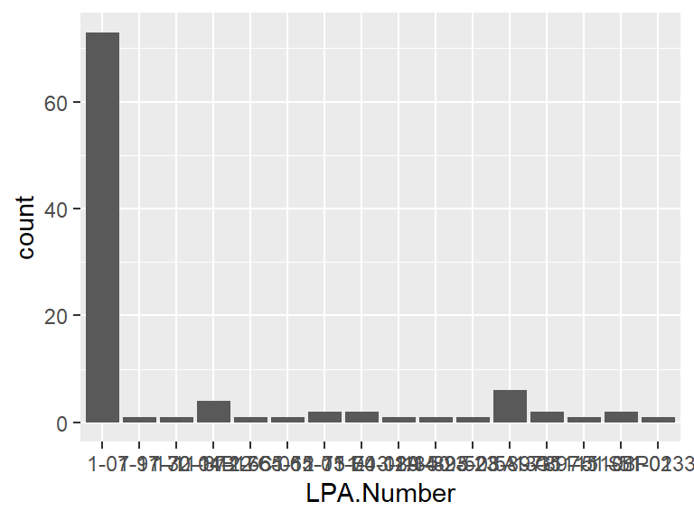

- The following suspected missing value codes enter as regular values: "".
- Note that the following levels have at most five observations: "1-07-97-32", "1-11-70-04B", "1-11-87-17C", "1-12-65-05", "1-12-65-65-01-E", …, "1-14-23-23 A - G", "5-13-89-15", "7-11-51-01", "7-11-51-02", "SBP01336" (4 values omitted).

## Purchase.Order.Number

- The variable is a key (distinct values for each observation).

## Acquisition.Type

| Feature | Result |
| --- | --- |
| Variable type | factor |
| Number of missing obs. | 0 (0 %) |
| Number of unique values | 3 |
| Mode | “NON-IT Goods” |
| Reference category | IT Goods |

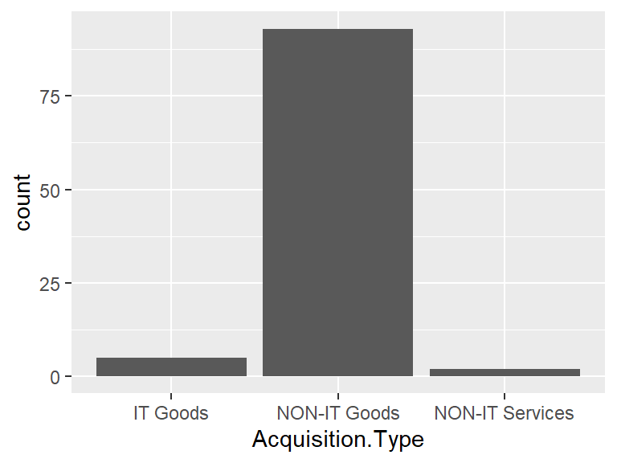

- Note that the following levels have at most five observations: "IT Goods", "NON-IT Services".

## Sub.Acquisition.Type

| Feature | Result |
| --- | --- |
| Variable type | factor |
| Number of missing obs. | 0 (0 %) |
| Number of unique values | 3 |
| Mode | “” |
| Reference category |  |

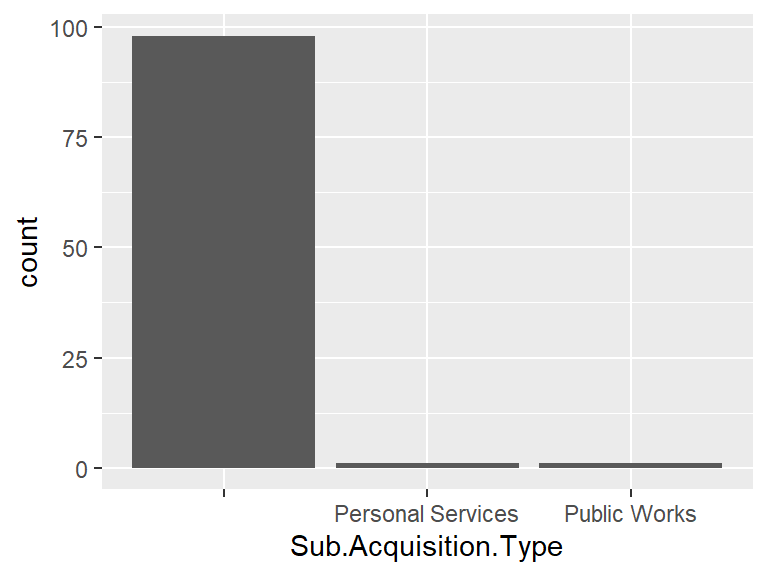

- The following suspected missing value codes enter as regular values: "".
- Note that the following levels have at most five observations: "Personal Services", "Public Works".

## Acquisition.Method

| Feature | Result |
| --- | --- |
| Variable type | factor |
| Number of missing obs. | 0 (0 %) |
| Number of unique values | 10 |
| Mode | “Informal Competitive” |
| Reference category | Fair and Reasonable |

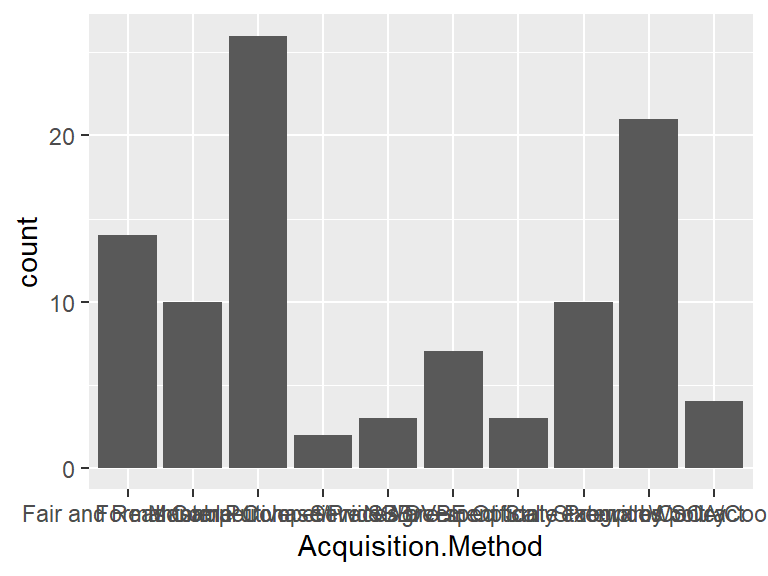

- Note that the following levels have at most five observations: "Master Purchase/Price Agreement", "NCB", "Services are specifically exempt by policy", "WSCA/Coop".

## Supplier.Code

| Feature | Result |
| --- | --- |
| Variable type | character |
| Number of missing obs. | 0 (0 %) |
| Number of unique values | 69 |
| Mode | “1755837” |

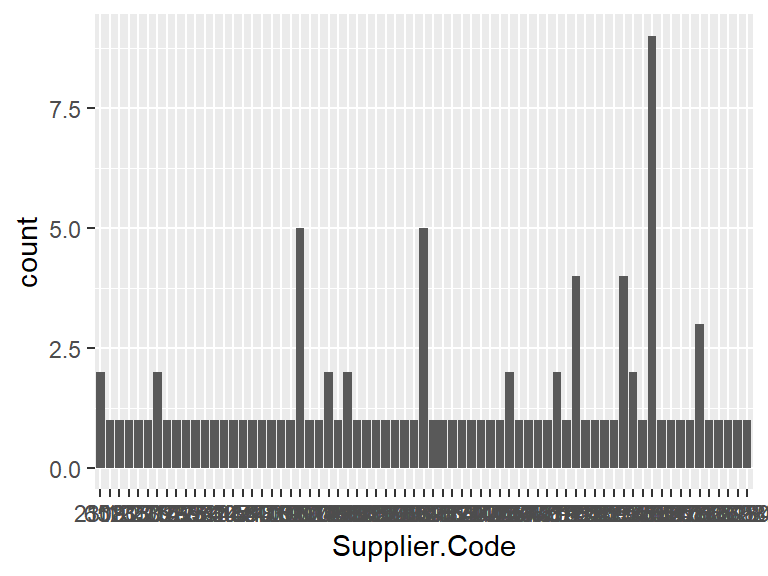

- Note that the following levels have at most five observations: "1000624", "1000709", "1000741", "1001493", "1001584", …, "45803", "47419", "47767", "48199", "6523" (58 values omitted).
- Note: The variable consists exclusively of numbers and takes a lot of different values. Is it perhaps a misclassified numeric variable?

## Supplier.Qualifications

| Feature | Result |
| --- | --- |
| Variable type | character |
| Number of missing obs. | 0 (0 %) |
| Number of unique values | 8 |
| Mode | “” |

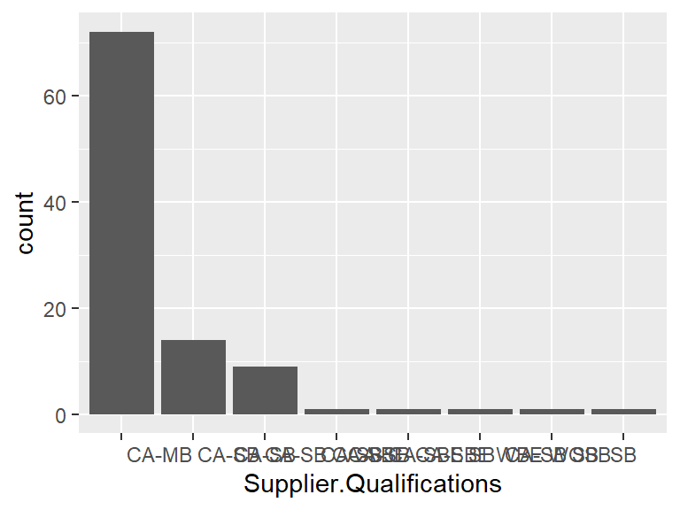

- The following suspected missing value codes enter as regular values: "".
- Note that the following levels have at most five observations: "CA-SB CA-SBE", "CA-SB CA-SBE SB", "CA-SB CA-SBE WBE WOSB", "CA-SB SB", "SB".

## Quantity

| Feature | Result |
| --- | --- |
| Variable type | numeric |
| Number of missing obs. | 0 (0 %) |
| Number of unique values | 34 |
| Median | 1.5 |
| 1st and 3rd quartiles | 1; 15.5 |
| Min. and max. | 1; 40000 |

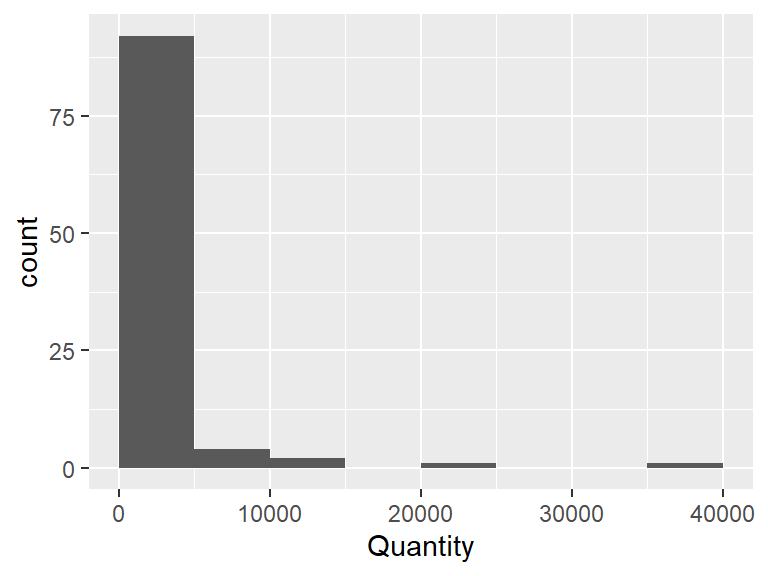

- Note that the following possible outlier values were detected: "462", "600", "1000", "6000", "6772.5", "10000", "10010", "14686.5", "20220.8", "40000".

## Unit.Price

| Feature | Result |
| --- | --- |
| Variable type | numeric |
| Number of missing obs. | 0 (0 %) |
| Number of unique values | 93 |
| Median | 279.5 |
| 1st and 3rd quartiles | 9.84; 6990.98 |
| Min. and max. | 0.04; 214788 |

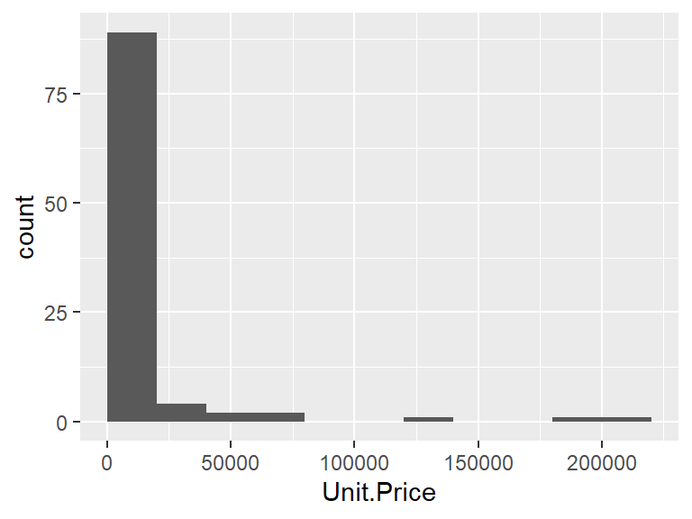

- Note that the following possible outlier values were detected: "199172.2", "214788".

## Total.Price

| Feature | Result |
| --- | --- |
| Variable type | numeric |
| Number of missing obs. | 0 (0 %) |
| Number of unique values | 98 |
| Median | 2819.2 |
| 1st and 3rd quartiles | 385.24; 12139.26 |
| Min. and max. | 3; 214788 |

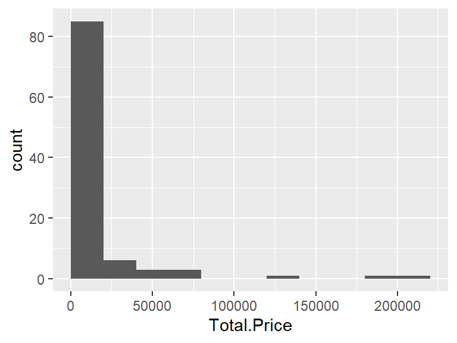

- Note that the following possible outlier values were detected: "137875", "199172.2", "214788".

## Classification.Codes

| Feature | Result |
| --- | --- |
| Variable type | character |
| Number of missing obs. | 0 (0 %) |
| Number of unique values | 75 |
| Mode | “56101504” |

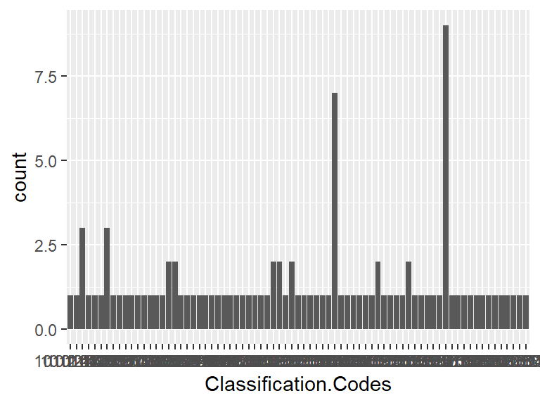

- Note that the following levels have at most five observations: "10101502", "10121505", "10121702", "10121703", "11121809", …, "81112201", "82101504", "82121506", "83101605", "93151512" (63 values omitted).
- Note: The variable consists exclusively of numbers and takes a lot of different values. Is it perhaps a misclassified numeric variable?

## Normalized.UNSPSC

| Feature | Result |
| --- | --- |
| Variable type | character |
| Number of missing obs. | 0 (0 %) |
| Number of unique values | 75 |
| Mode | “56101504” |

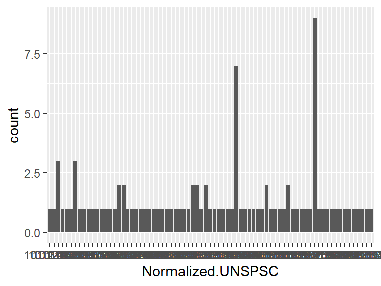

- Note that the following levels have at most five observations: "10101502", "10121505", "10121702", "10121703", "11121809", …, "81112201", "82101504", "82121506", "83101605", "93151512" (63 values omitted).
- Note: The variable consists exclusively of numbers and takes a lot of different values. Is it perhaps a misclassified numeric variable?

## Commodity.Title

| Feature | Result |
| --- | --- |
| Variable type | character |
| Number of missing obs. | 0 (0 %) |
| Number of unique values | 75 |
| Mode | “Chairs” |

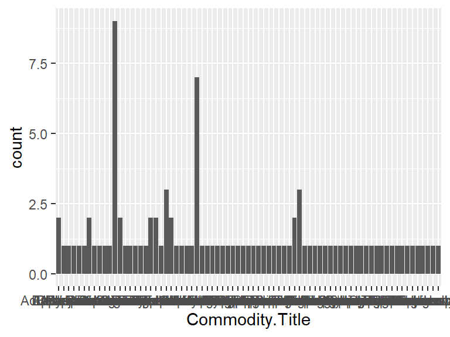

- Note that the following levels have at most five observations: "Adult diapers", "Apple juice", "Arm chair", "Baby bananas", "Ball point pens", …, "Vehicle rental", "Wax beans", "Wear bushing", "Window envelopes", "Wooden pencils" (63 values omitted).

## Class

| Feature | Result |
| --- | --- |
| Variable type | factor |
| Number of missing obs. | 0 (0 %) |
| Number of unique values | 58 |
| Mode | “56101500” |
| Reference category | 10101500 |

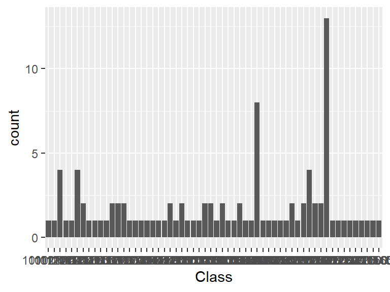

- Note that the following levels have at most five observations: "10101500", "10121500", "10121700", "11121800", "12161700", …, "81112200", "82101500", "82121500", "83101600", "93151500" (46 values omitted).
- Note: The variable consists exclusively of numbers and takes a lot of different values. Is it perhaps a misclassified numeric variable?

## Class.Title

| Feature | Result |
| --- | --- |
| Variable type | character |
| Number of missing obs. | 0 (0 %) |
| Number of unique values | 58 |
| Mode | “Furniture” |

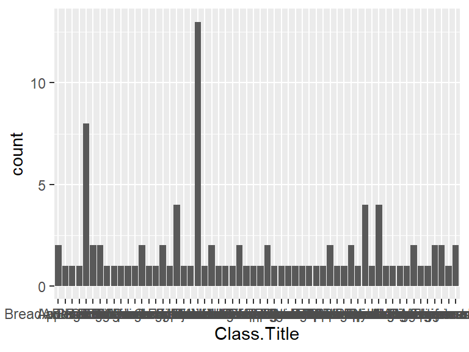

- Note that the following levels have at most five observations: "Apples", "Awards", "Bags", "Bananas", "Bolts", …, "Tape", "Undergarments", "Uniforms", "Wrenches and drivers", "Writing instruments" (46 values omitted).

## Family

| Feature | Result |
| --- | --- |
| Variable type | factor |
| Number of missing obs. | 0 (0 %) |
| Number of unique values | 36 |
| Mode | “56100000” |
| Reference category | 10100000 |

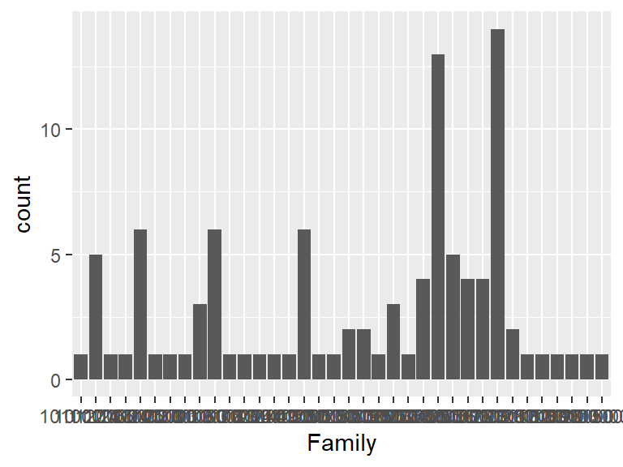

- Note that the following levels have at most five observations: "10100000", "10120000", "11120000", "12160000", "15100000", …, "81110000", "82100000", "82120000", "83100000", "93150000" (21 values omitted).
- Note: The variable consists exclusively of numbers and takes a lot of different values. Is it perhaps a misclassified numeric variable?

## Family.Title

| Feature | Result |
| --- | --- |
| Variable type | character |
| Number of missing obs. | 0 (0 %) |
| Number of unique values | 36 |
| Mode | “Accommodation furniture” |

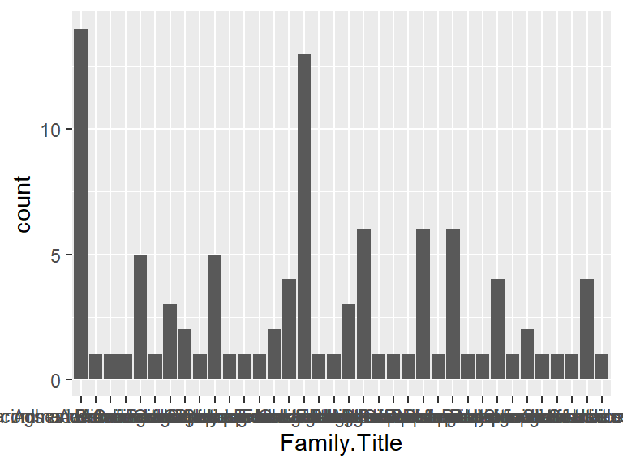

- Note that the following levels have at most five observations: "Additives", "Adhesives and sealants", "Advertising", "Animal feed", "Bearings and bushings and wheels and gears", …, "Reproduction services", "Seafood", "Seals", "Signage and accessories", "Utilities" (21 values omitted).

## Segment

| Feature | Result |
| --- | --- |
| Variable type | factor |
| Number of missing obs. | 0 (0 %) |
| Number of unique values | 21 |
| Mode | “50000000” |
| Reference category | 10000000 |

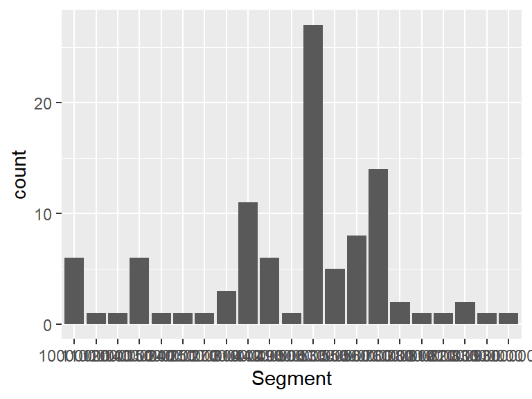

- Note that the following levels have at most five observations: "11000000", "12000000", "15000000", "24000000", "25000000", …, "78000000", "81000000", "82000000", "83000000", "93000000" (4 values omitted).
- Note: The variable consists exclusively of numbers and takes a lot of different values. Is it perhaps a misclassified numeric variable?

## Segment.Title

| Feature | Result |
| --- | --- |
| Variable type | factor |
| Number of missing obs. | 0 (0 %) |
| Number of unique values | 21 |
| Mode | “Food Beverage and Tobacco Products” |
| Reference category | Apparel and Luggage and Personal Care Products |

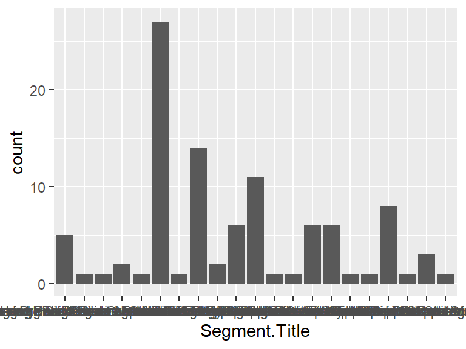

- Note that the following levels have at most five observations: "Apparel and Luggage and Personal Care Products", "Chemicals including Bio Chemicals and Gas Materials", "Commercial and Military and Private Vehicles and their Accessories and Components", "Editorial and Design and Graphic and Fine Art Services", "Engineering and Research and Technology Based Services", …, "Politics and Civic Affairs Services", "Public Utilities and Public Sector Related Services", "Sports and Recreational Equipment and Supplies and Accessories", "Tools and General Machinery", "Transportation and Storage and Mail Services" (4 values omitted).

Report generation information:

- Created by: Analytics Enlightened LLC (username: `redbe`).
- Report creation time: Wed Mar 13 2024 14:25:14
- Report was run from directory: `C:/Users/redbe/OneDrive/Documents/Data`
- dataMaid v1.4.1 [Pkg: 2021-10-08 from CRAN (R 4.3.1)]
- R version 4.3.1 (2023-06-16 ucrt).
- Platform: x86_64-w64-mingw32/x64 (64-bit)(America/New_York).
- Function call: `makeDataReport(data = purchase_order, output = "html", replace = TRUE)`